# Statystyki

Marta J??wik, Ewa Baranowska

31 marca 2017

# Zadanie 3

Dla ka?dego zdania w podziale na kraje znajdujemy statystyki. Zobaczmy kilka przyk?ad?w:

Patrz?c na ?rednie czasy rozwi?zywania r??nych rodzaj?w zada? wida?, ?e zar?wno og?lnie jak i w rozbiciu na poszczeg?lne kontynenty ?redni czas rozwi?zywania zada? z matematyki jest najd?u?szy, a czytanie i nauki ?cis?e maj? podobny ?redni czas.

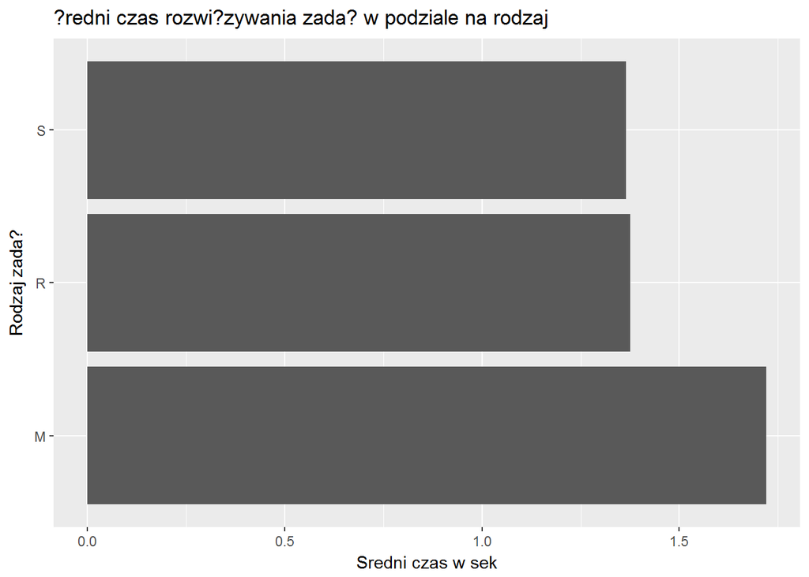

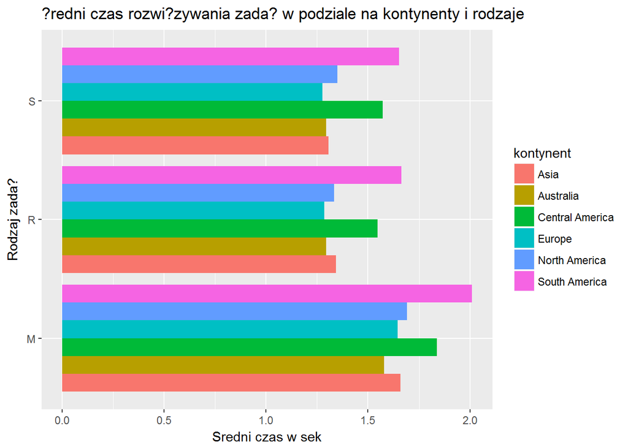

Zobaczmy teraz jak wygl?da ?reni czas rozwi?zywania 1 zadania w podziale na kraje.

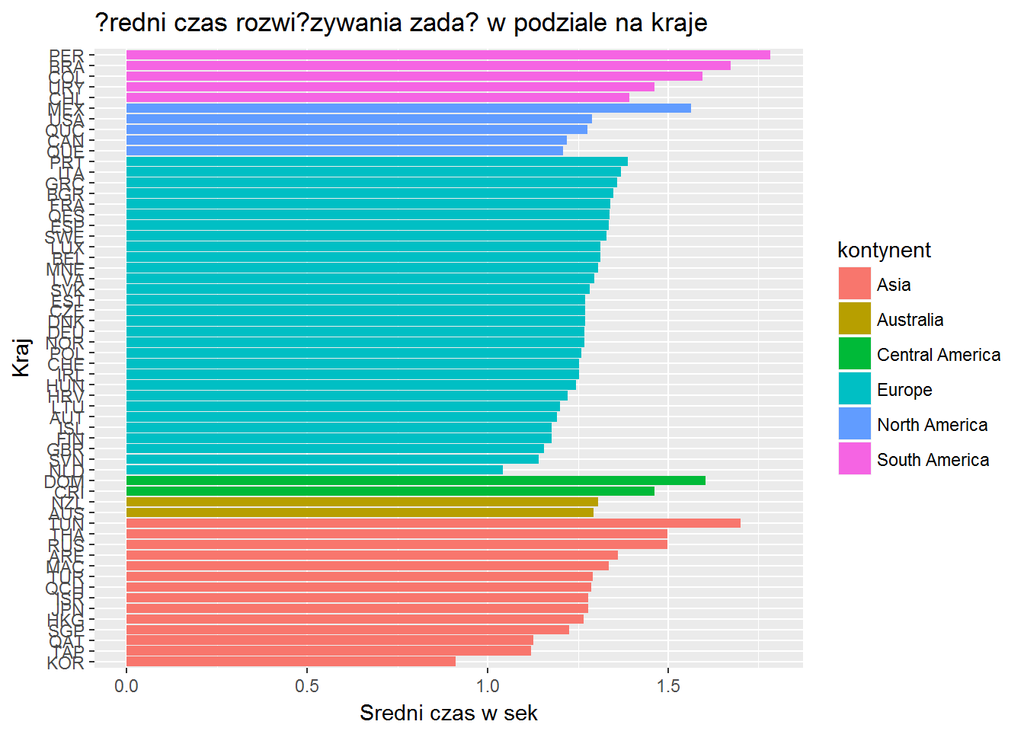

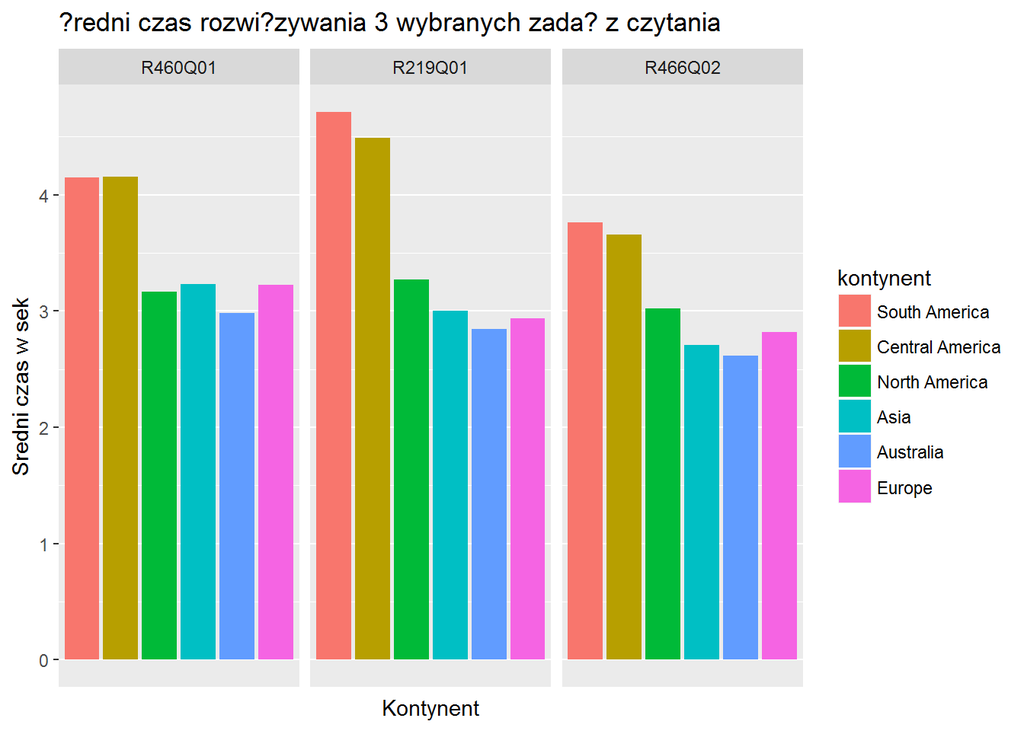

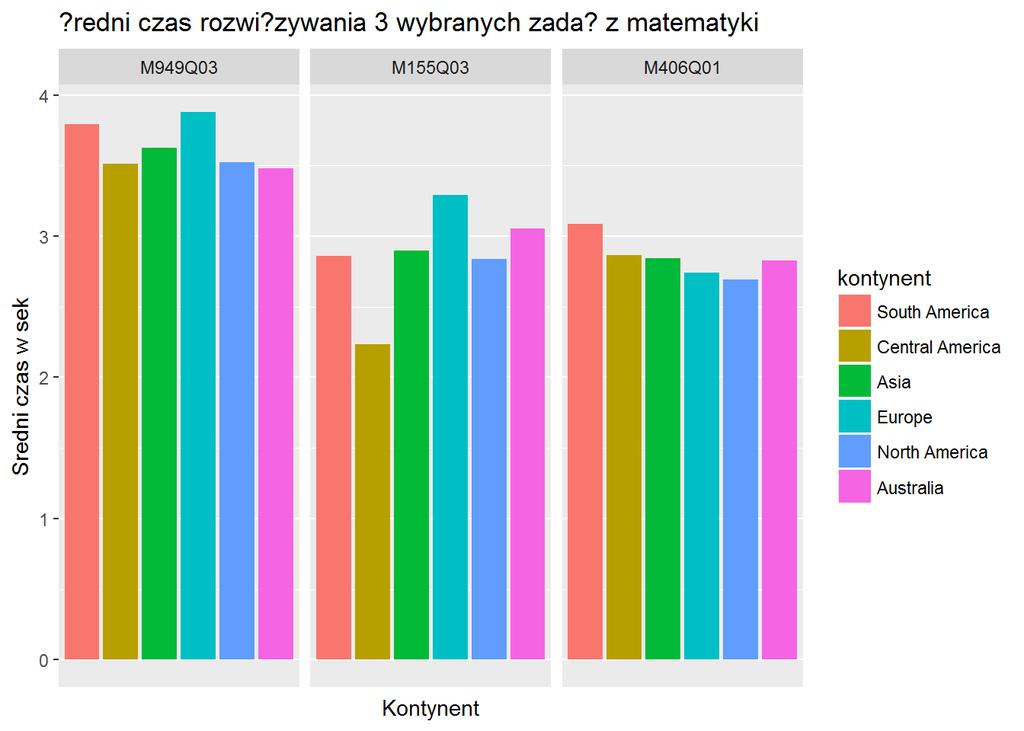

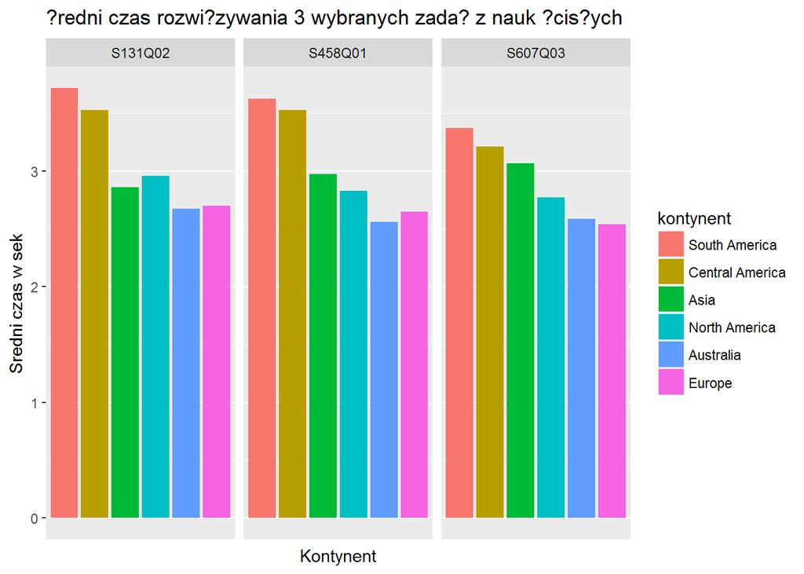

Teraz obejrzyjmy te wykresy dla kilku wybranych kraj?w

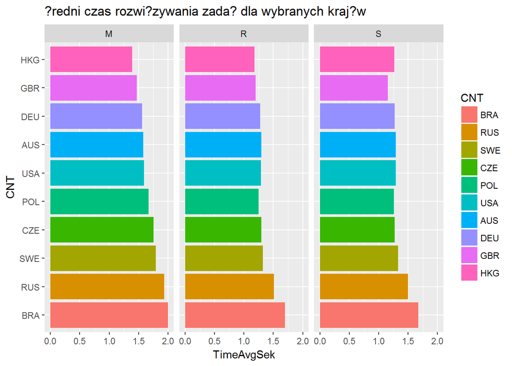

Mo?na zauwa?y?, ?e ‘czo??wka’ i ‘koniec stawki’ zn?w pozostaj? prawie takie same niezale?nie od rodzaju zadania.

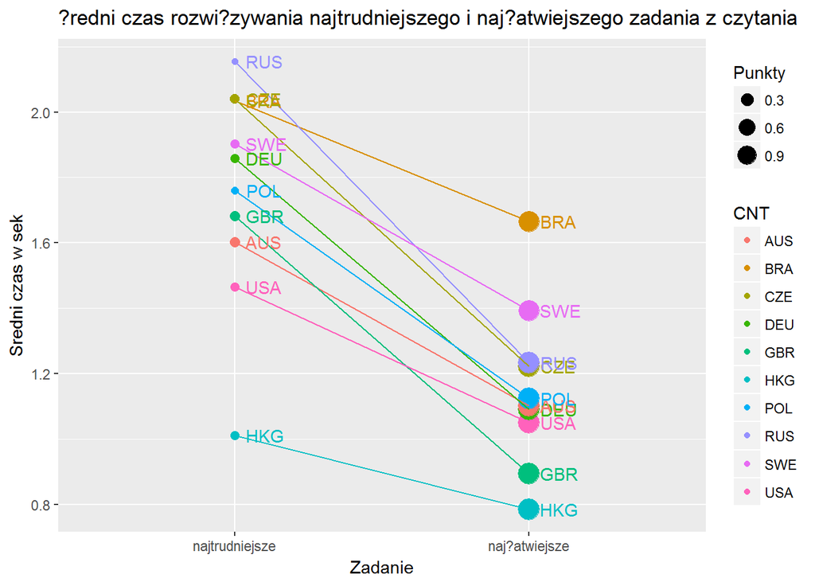

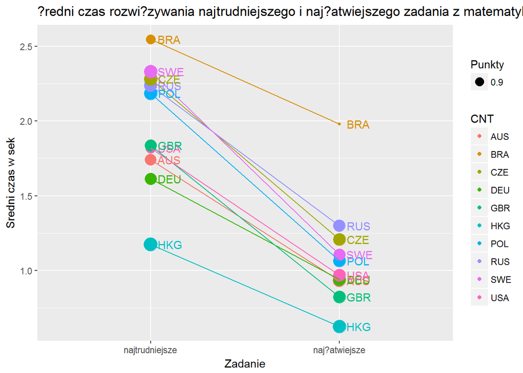

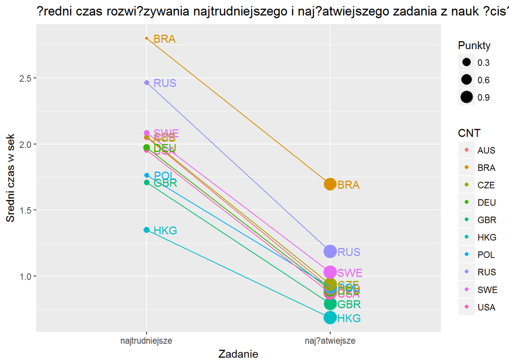

Warto r?wnie? przyjrze? si? wp?ywowi p?ci na czasy rozwi?zywania zada?. Wydaje si? ?e dziewczynki zwykle rozwi?zuj? zadania z czytania i nauk ?cis?ych d?u?ej ni? ch?opcy, matematyka jest rozwi?zywana w podobnym czasie.

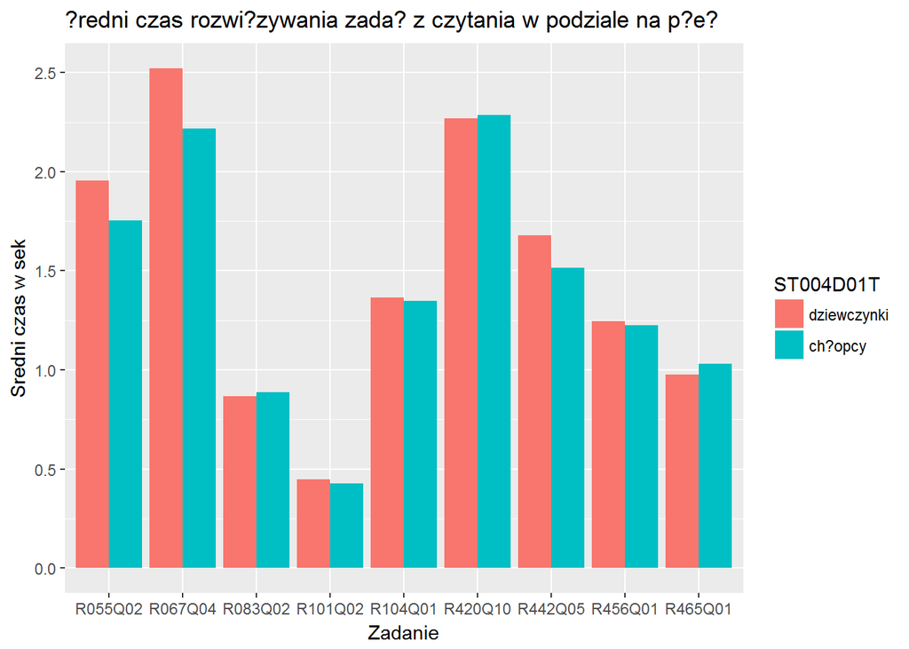

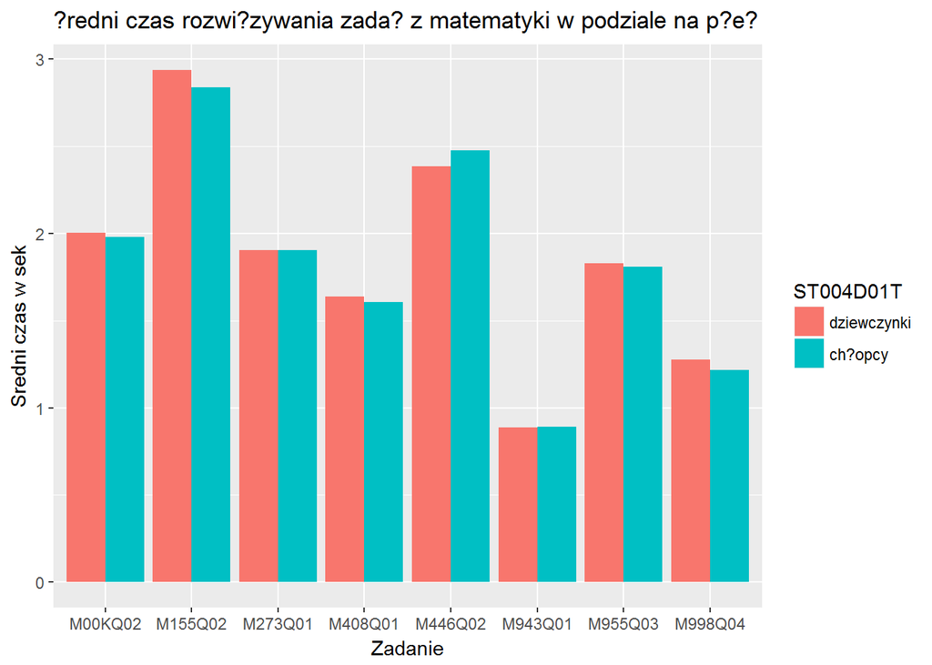

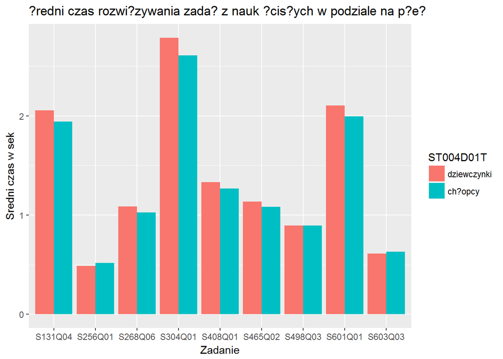

R?wnie? ciekawe b?dzie spojrzenie na?rednie czasy przy r??nych zadeklarowanych poziomach zdenerwowania. wydaje si? ?e ci kt?rzy malo sie denerwowali powinni rozwi?zywa? zadania szybciej, jednak w wi?kszo?ci przypadk?w r??nice s? tak nieiwielkie, ?e mo?emy w?asciwie m?wi? o braku r??nic.

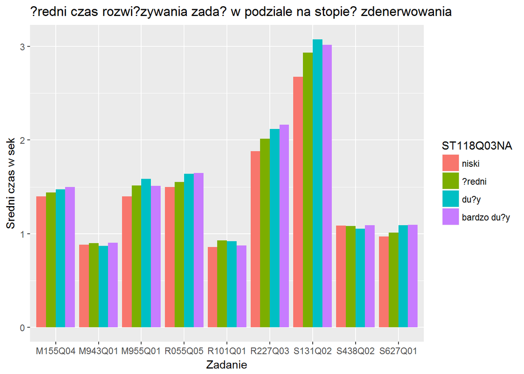

# zadanie 3.5

Rozwa?ymy teraz ?rednie czasy rozwi?zywania zada? w zale?no?ci od pozycji na kt?rej si? znajdywa?y.

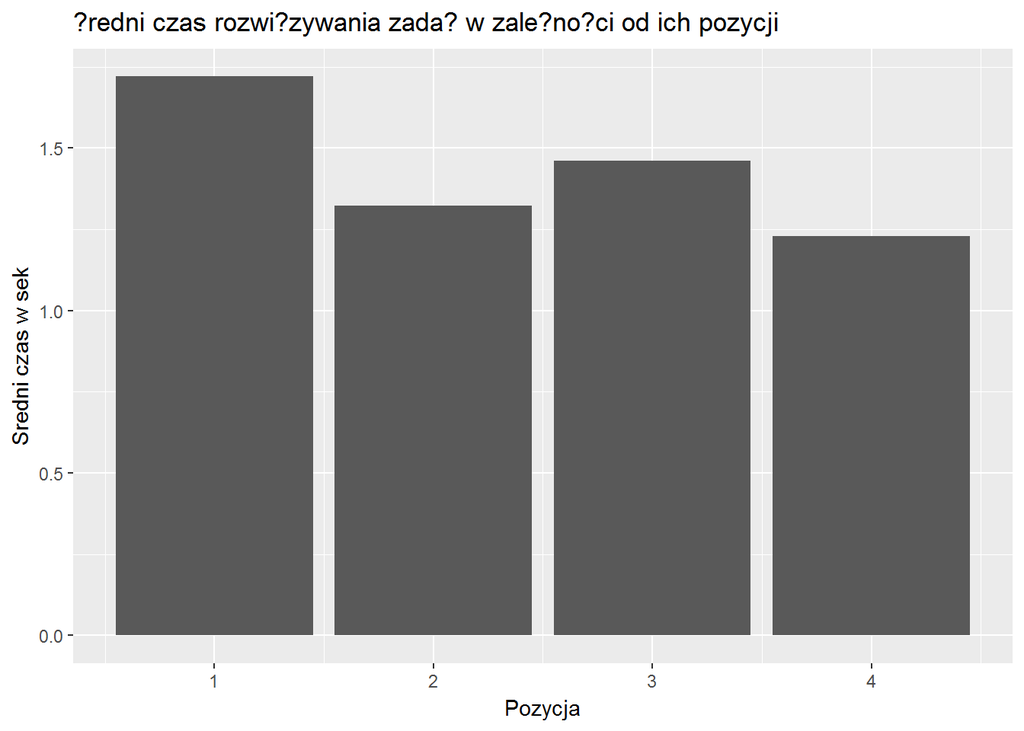

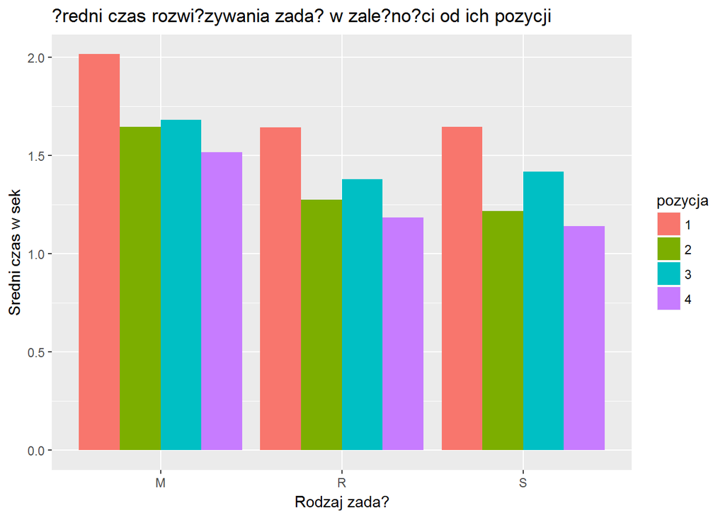

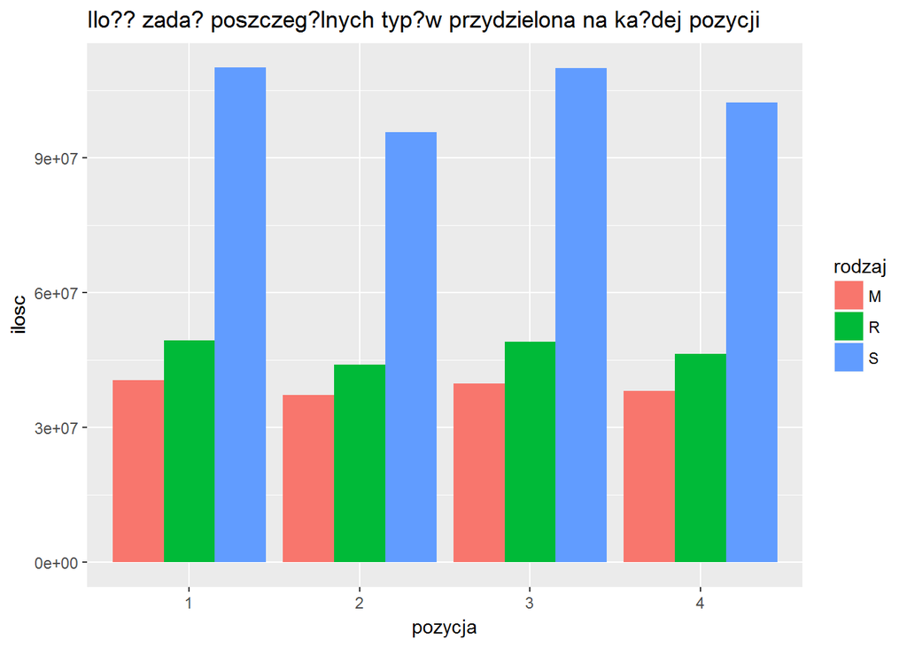

Wida?, ?e zadania na pozycji 1 s? ?rednio rozwi?zywane d?u?ej ni? pozosta?e, nast?pnie nast?puje skr?cenie czasu (mo?liwe ?e uczniowie s? ju? wprawieni), potem zn?w wzrost (np. z powodu zm?czenia),a te na pozycji 4 s? rozwi?zywane najkr?cej (np. uczniowe spiesz? si? poniewa? zbli?a si? koniec egzaminu). Rozbijaj?c zadania na posczeg?lne typy widzimy identyczn? zale?no??. Mo?na wi?c wywnioskowa?, ?e rodzaj zada? przydzielonych do danego klastra nie ma znaczenia, poniewa? wiemy ?e proporcje obserwcji z zadaniami posczeg?lnych typ?w w danym klastrze s? podobne.

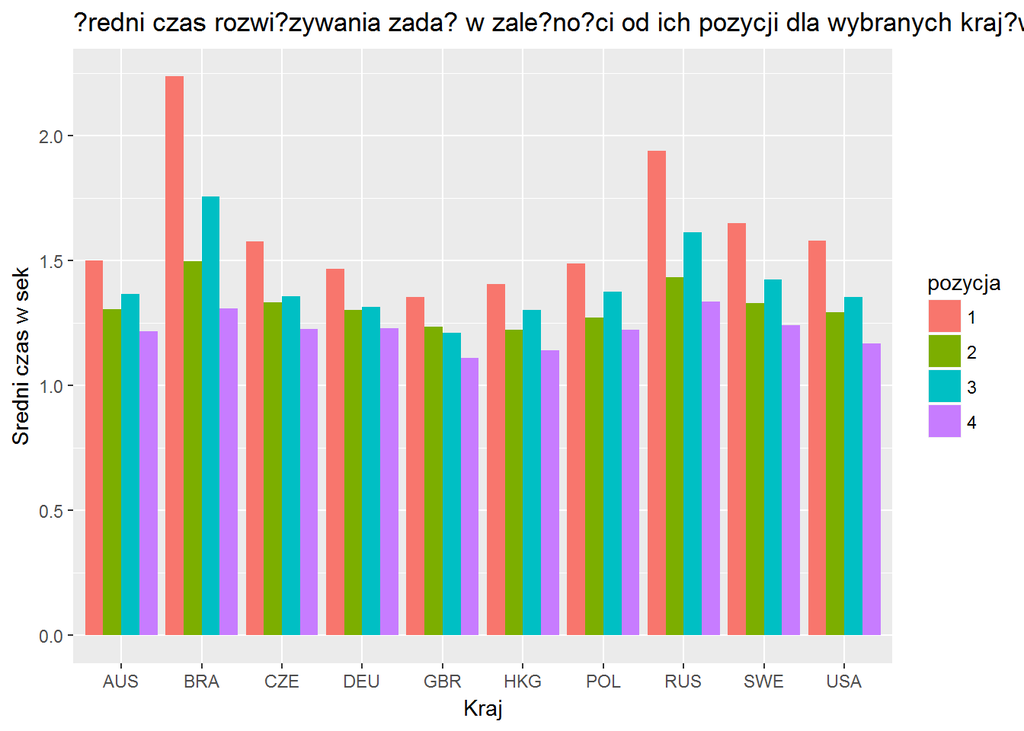

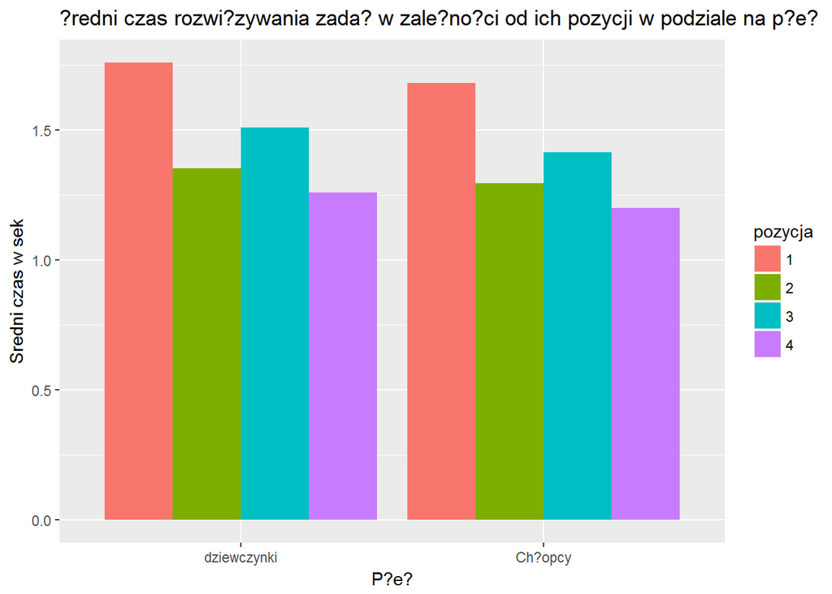

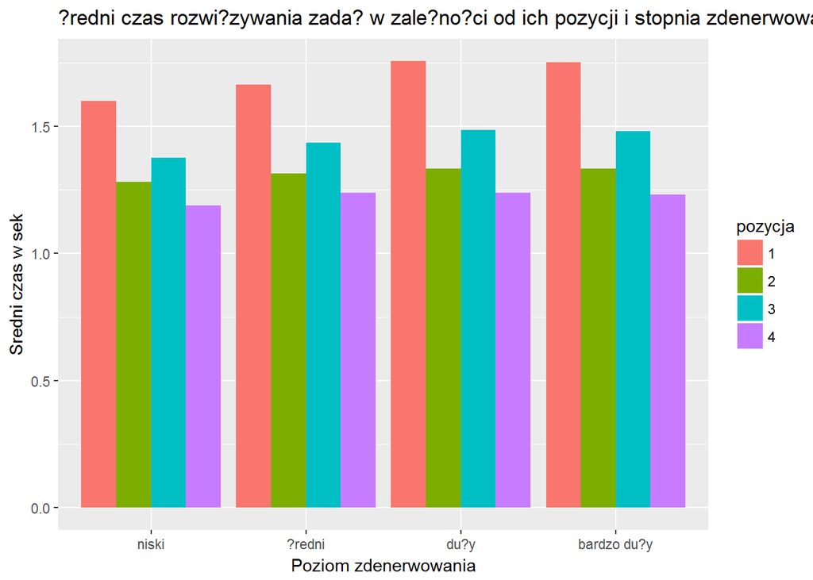

# ZADANIE 4

# POMYSL 1

1. obliczamy ile zadan uczen probowal rozwiazac a ile nie (score=NA)
2. obliczamy na ktorym klastrze zabraklo mu czasu
3. na tej podstawie zobaczymy po krajach ktore dzieci rozwiazuja bardzo szybko (czas konczyl im sie w 4 czesci testu albo wogole), a ktore wolniej (czas konczyl sie w 3 cz. itd.) - mozemy porownac ilosci poprawnych odpowiedzi i zobaczyc czy oplaca sie leciec przez test szybciej (i pewnie z wieksza iloscia bledow) czy wolniej ale bardziej dokladnie

# POMYSL 2

zsumowac czasy poswiecane na kazdy klaster i zobaczyc czy sa osoby ktore 1 klaster rozwiazywaly najdluzej, czy moze wlasnie najszybciej itp. czyli roklad czasu rozwiazywania poszczegolnych klastrow

# POMYSL 3

Czy sa uczniowe ktorzy jesli maja bledne odpowiedzi to maja one malutki czas - tzn od razu widza ze nie rozwiaza i po prostu strzelaja albo inaczej, czy jesli dlugo sie zastanawiaja to czy odpowiedz bedzie poprawna

# POMYSL 4

Zobaczyc czy sa uczniowie bardzo dobrze radza sobie z matematyki (duzy odsetek poprawnych odpowiedzi) i zobaczyc czy poswiecaja na klaster z matematyka wiecej czasu srednio niz na inne klastry, a moze wrecz przeciwnie, matematyka idzie im bardzo szybko

# Pytania

Czy zbiory z uczniami o poszczeg?lnych strategiach musz? by? roz??czne? Czy wykorzystywa? wszytskie 4 pomys?y czy skupi? si? na jednym?